# Mesh Denoising

# Mesh Denoising

Smooth noisy vertex positions using discrete differential operators on a triangulated surface. Compare the geometric effect of the updates and inspect how the choice of weights influences detail preservation and shrinkage.

## Run this tour

Run the cells in order with a Python 3 kernel. The first cell locates the companion data and toolbox and installs missing dependencies when needed. All worked examples include their implementation directly in this notebook. Random seeds make comparisons reproducible; you can change them to explore other samples.

```python
# Locate the companion toolbox locally, or fetch it for a standalone/Colab copy.
from pathlib import Path
import importlib.util
import os
import subprocess
import sys

working = Path.cwd()
candidates = [working, working / "python", working.parent / "python"]
python_dir = next((p for p in candidates if (p / "nt_toolbox").is_dir()), None)
if python_dir is None:
    checkout = working / "numerical-tours-support"
    if not checkout.exists():
        subprocess.run(
            [
                "git",
                "clone",
                "--depth",
                "1",
                "--branch",
                "master",
                "https://github.com/gpeyre/numerical-tours.git",
                str(checkout),
            ],
            check=True,
        )
    python_dir = checkout / "python"
os.chdir(python_dir)
if str(python_dir) not in sys.path:
    sys.path.insert(0, str(python_dir))
requirements = python_dir / "requirements.txt"
if any(
    importlib.util.find_spec(name) is None
    for name in [
        "numpy",
        "scipy",
        "matplotlib",
        "skimage",
        "sklearn",
        "pywt",
        "ipywidgets",
        "cvxpy",
        "skfmm",
        "autograd",
        "progressbar",
        "celer",
    ]
):
    subprocess.run(
        [sys.executable, "-m", "pip", "install", "-r", str(requirements)], check=True
    )

import numpy as np
import matplotlib.pyplot as plt

np.random.seed(0)
plt.rcParams.update(
    {
        "figure.figsize": (8, 4),
        "figure.dpi": 100,
        "axes.spines.top": False,
        "axes.spines.right": False,
        "font.size": 11,
        "image.cmap": "gray",
    }
)
%matplotlib inline
```

$\newcommand{\dotp}[2]{\langle #1, #2 \rangle}$ $\newcommand{\enscond}[2]{\lbrace #1, #2 \rbrace}$ $\newcommand{\pd}[2]{ \frac{ \partial #1}{\partial #2} }$ $\newcommand{\umin}[1]{\underset{#1}{\min}\;}$ $\newcommand{\umax}[1]{\underset{#1}{\max}\;}$ $\newcommand{\uargmin}[1]{\underset{#1}{argmin}\;}$ $\newcommand{\norm}[1]{\|#1\|}$ $\newcommand{\abs}[1]{\left|#1\right|}$ $\newcommand{\choice}[1]{ \left\{ \begin{array}{l} #1 \end{array} \right. }$ $\newcommand{\pa}[1]{\left(#1\right)}$ $\newcommand{\diag}[1]{{diag}\left( #1 \right)}$ $\newcommand{\qandq}{\quad\text{and}\quad}$ $\newcommand{\qwhereq}{\quad\text{where}\quad}$ $\newcommand{\qifq}{ \quad \text{if} \quad }$ $\newcommand{\qarrq}{ \quad \Longrightarrow \quad }$ $\newcommand{\ZZ}{\mathbb{Z}}$ $\newcommand{\CC}{\mathbb{C}}$ $\newcommand{\RR}{\mathbb{R}}$ $\newcommand{\EE}{\mathbb{E}}$ $\newcommand{\Zz}{\mathcal{Z}}$ $\newcommand{\Ww}{\mathcal{W}}$ $\newcommand{\Vv}{\mathcal{V}}$ $\newcommand{\Nn}{\mathcal{N}}$ $\newcommand{\NN}{\mathcal{N}}$ $\newcommand{\Hh}{\mathcal{H}}$ $\newcommand{\Bb}{\mathcal{B}}$ $\newcommand{\Ee}{\mathcal{E}}$ $\newcommand{\Cc}{\mathcal{C}}$ $\newcommand{\Gg}{\mathcal{G}}$ $\newcommand{\Ss}{\mathcal{S}}$ $\newcommand{\Pp}{\mathcal{P}}$ $\newcommand{\Ff}{\mathcal{F}}$ $\newcommand{\Xx}{\mathcal{X}}$ $\newcommand{\Mm}{\mathcal{M}}$ $\newcommand{\Ii}{\mathcal{I}}$ $\newcommand{\Dd}{\mathcal{D}}$ $\newcommand{\Ll}{\mathcal{L}}$ $\newcommand{\Tt}{\mathcal{T}}$ $\newcommand{\si}{\sigma}$ $\newcommand{\al}{\alpha}$ $\newcommand{\la}{\lambda}$ $\newcommand{\ga}{\gamma}$ $\newcommand{\Ga}{\Gamma}$ $\newcommand{\La}{\Lambda}$ $\newcommand{\Si}{\Sigma}$ $\newcommand{\be}{\beta}$ $\newcommand{\de}{\delta}$ $\newcommand{\De}{\Delta}$ $\newcommand{\phi}{\varphi}$ $\newcommand{\th}{\theta}$ $\newcommand{\om}{\omega}$ $\newcommand{\Om}{\Omega}$

This tour explores denoising of 3-D meshes using linear filtering, heat diffusion and Sobolev regularization.

```python
import numpy as np
import scipy as scp
import pylab as pyl
import matplotlib.pyplot as plt

from nt_toolbox.general import np, plt, pylab, rescale
from nt_toolbox.signal import load_image, np, plt, pylab, snr

import warnings

%matplotlib inline
```

## 3-D Triangulated Meshes

The topology of a triangulation is defined via a set of indexes $\Vv = \{1,\ldots,n\}$ that indexes the $n$ vertices, a set of edges $\Ee \subset \Vv \times \Vv$ and a set of $m$ faces $\Ff \subset \Vv \times \Vv \times \Vv$.

We load a mesh. The set of faces $\Ff$ is stored in a matrix $F \in \{1,\ldots,n\}^{3 \times m}$. The positions $x_i \in \RR^3$, for $i \in V$, of the $n$ vertices are stored in a matrix $X_0 = (x_{0,i})_{i=1}^n \in \RR^{3 \times n}$.

```python
from nt_toolbox.read_mesh import np, read_mesh

X0, F = read_mesh("nt_toolbox/data/elephant-50kv.off")
```

Number $n$ of vertices and number $m$ of faces.

```python
n = np.shape(X0)[1]
m = np.shape(F)[1]
```

Display the mesh in 3-D.

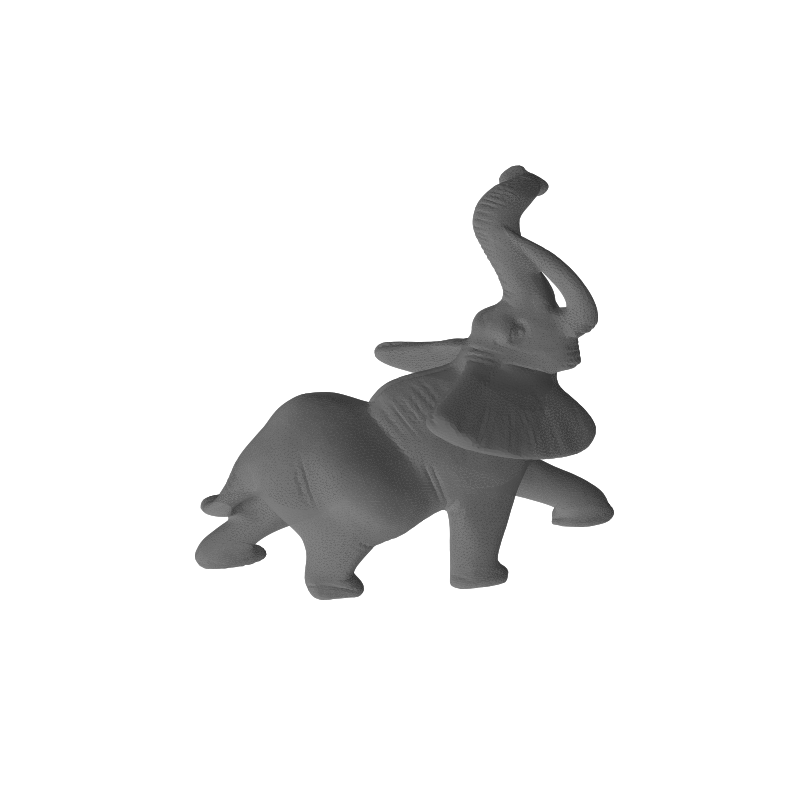

```python
from nt_toolbox.plot_mesh import np, plot_mesh, plt

plt.figure(figsize=(10, 10))
plot_mesh(X0, F)
```

## Noisy Mesh

We generate artificially a noisy mesh by random normal displacement along the normal. We only perform normal displacements because tangencial displacements do not impact the geometry of the mesh.

The parameter $\rho>0$ controls the amount of noise.

```python
rho = 0.015
```

We compute the normals $N = (N_i)_{i=1}^n$ to the mesh. This is obtained by averaging the normal to the faces ajacent to each vertex.

```python
from nt_toolbox.compute_normal import compute_normal, np

N = compute_normal(X0, F)
```

We create a noisy mesh by displacement of the vertices along the normal direction $$ x_i = x_{0,i} + \rho \epsilon_i N_i \in \RR^3 $$ where $\epsilon_i \sim \Nn(0,1)$ is a realization of a Gaussian random variable, and where $N_i \in \RR^3$ is the normal of the mesh for each vertex index $i$.

```python
from numpy import random

X = X0 + np.tile(rho * random.randn(n), (3, 1)) * N
```

Display the noisy mesh.

[figure not shown]

```python
plt.figure(figsize=(10, 10))
plot_mesh(X, F)
```

## Adjacency Matrix

We define linear operators that compute local averages and differences on the mesh.

First we compute the index of the edges that are in the mesh, by extracting pairs of index in the $F$ matrix.

```python
E = np.hstack((F[[0, 1], :], F[[1, 2], :], F[[2, 0], :]))
```

Add the reversed edges. This defines the set of edges $\Ee$ that is stored in a matrix $E \in \{1,\ldots,n\}^{2 \times p}$.

```python
from nt_toolbox.unique_columns import np, unique_columns

E = unique_columns(np.hstack((E, E[[1, 0], :])))
```

We keep only oriented pairs of index $(i,j)$ such that $i<j$, to avoid un-necessary computation.

```python
E0 = E[:, E[0, :] < E[1, :]]
```

This defines a matrix $E \in \{1,\ldots,n\}^{2 \times p_0}$ where $p_0=p/2$.

```python
p0 = np.shape(E0)[1]
```

Display statistics of the mesh.

```python
print("#vertices = %i, #faces = %i, #edges = %i" % (n, m, p0))
```

```
#vertices = 24955, #faces = 49918, #edges = 74877
```

The weight matrix $W$ is the adjacency matrix defined by $$ W_{i,j} = \choice{ 1 \qifq (i,j) \in \Ee, \\ 0 \quad \text{otherwise.} } $$ Since most of the entries of $W$ are zero, we store it as a sparse matrix.

```python
from scipy import sparse

W = sparse.coo_matrix((np.ones(np.shape(E)[1]), (E[0, :], E[1, :])))
```

Compute the connectivity weight vector $ d \in \NN^n $ $$ d_i = \sum_{j} W_{i,j} $$ i.e. $d_i$ is the number of edges connected to $i$.

```python
d = np.ravel((W.sum(0)))
```

Display the statistics of mesh connectivity.

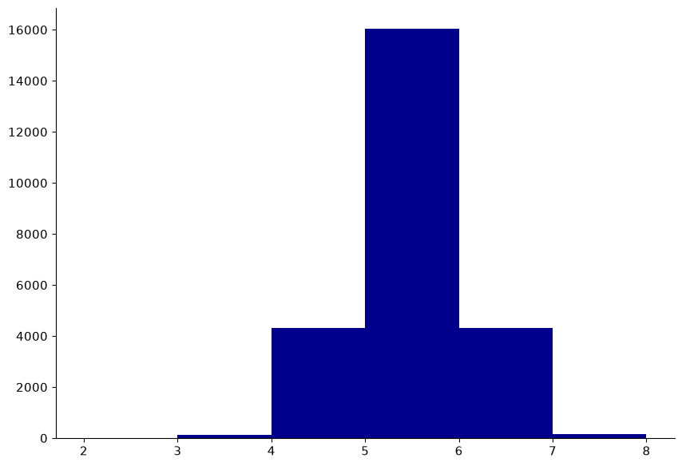

```python
h = np.histogram(d, np.arange(np.min(d), np.max(d) + 1))

plt.figure(figsize=(10, 7))
plt.bar(h[1][:-1] - 0.5, h[0], color="darkblue", width=1)
plt.show()
```

Store in sparse diagonal matices $D$ and $iD$ respectively $D=\text{diag}_i(d_i)$ and $D^{-1} = \text{diag}_i(1/d_i)$.

```python
D = sparse.coo_matrix((d, (np.arange(0, n), np.arange(0, n))))
iD = sparse.coo_matrix((1 / d, (np.arange(0, n), np.arange(0, n))))
```

The normalized weight matrix is defined as $$ \tilde W_{i,j} = \frac{1}{d_i} W_{i,j}, $$ and hence $\tilde W = D^{-1} W$.

```python
tW = iD.dot(W)
```

It satisfies $$ \forall i , \quad \sum_j \tilde W_{i,j} = 1, $$ i.e. $\tilde W \text{I} = \text{I}$ where $\text{I} \in \RR^n$ is the vector constant equal to one.

The operator $\tilde W \in \RR^{n \times n} $, viewed as an operator $\tilde W : \RR^n \rightarrow \RR^n$, can be thought as a low pass filter.

## Laplacian and Gradient Operators

The un-normalized Laplacian is on the contrary a symmetric high pass operator $$ L = D-W \in \RR^{n \times n}. $$ It satisfies $L \text{I} = 0$.

```python
L = D - W
```

The gradient operator compute directional derivative along edges. It can be used to factor the Laplacian operator, but in practice it is never computed explicitely since it is never needed in numerical computation.

To represent the gradient, we index the set of (oriented) edges $ \Ee_0 = (e_k)_{k=1}^{p_0} $ where each edge is $e_k = (i,j) \in \{1,\ldots,n\}^2$ with $i<j$.

The gradient operator is a matrix $G \in \RR^{p_0 \times n}$ defined as, for all $e_k=(i,j)$ and all $\ell \notin \{i,j\}$, $$ G_{k,i}=1, \quad G_{k,j}=-1, \quad G_{k,\ell}=0. $$

It is stored as a sparse matrix, and can be thought as a derivative operator $G : \RR^n \rightarrow \RR^{p_0} $ that maps signal defined on vertices to differences located along directed edges.

```python
G = sparse.coo_matrix(
    (
        np.hstack((np.ones(p0), -np.ones(p0))),
        (
            np.hstack((np.arange(0, p0), np.arange(0, p0))),
            np.hstack((E0[0, :], E0[1, :])),
        ),
    )
)
```

Display the non-zero entries of $G$ and $W$.

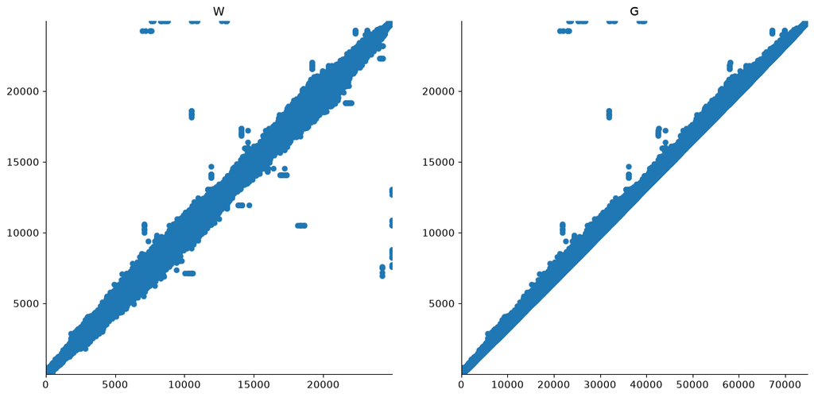

```python
plt.figure(figsize=(15, 7))

plt.subplot(1, 2, 1)
plt.scatter(sparse.find(W)[0], sparse.find(W)[1], lw=0.3)
plt.xlim(0, np.shape(W)[0])
plt.ylim(1, np.shape(W)[1])
plt.title("W")

plt.subplot(1, 2, 2)
plt.scatter(sparse.find(G)[0], sparse.find(G)[1], lw=0.3)
plt.xlim(0, np.shape(G)[0])
plt.ylim(1, np.shape(G)[1])
plt.title("G")

plt.show()
```

The Laplacian can be factored as follow $$ L = G^* G $$ where $G^*$ is the transposed matrix (i.e. the adjoint operator, which can be thought as some kind of divergence).

Check numerically that the factorization indeed hold.

```python
err = sparse.linalg.norm((np.dot(np.transpose(G), G) - L), "fro")
print("Factorization error (should be 0) = %.2f" % err)
```

```
Factorization error (should be 0) = 0.00
```

Note that this factorization shows that $L$ is a positive semi-definite operator, i.e. it satisfies

$$ \dotp{L f}{f} = \norm{G f}^2 \geq 0. $$

If the mesh is connected, then only constant signals $f \in \RR^n$ satisfies $Lf=0$.

Note that this convention is the contrary to the usual convention of differential calculus, in which a Laplacian is a negative operator.

## Function Denoising with Filtering

A signal defined on the mesh is a vector $f \in \RR^n$, where $f_i \in \RR$ is the value at vertex $1 \leq i \leq n$.

Load a texture image $I$.

```python
M = load_image("nt_toolbox/data/lena.png", 256)
```

Compute spherical coordinates $ (\theta_i,\phi_i)$ for each vertex $x_{0,i}$ on the mesh.

```python
v = X0 - np.tile(np.mean(X0, 1)[:, np.newaxis], (1, n))
theta = np.arccos(v[0, :] / np.sqrt(np.sum(v**2, 0))) / np.pi
phi = (np.arctan2(v[1, :], v[2, :]) / np.pi + 1) / 2.0
```

Interpolate the texture on the mesh.

```python
from scipy import interpolate
from matplotlib import colors

x = np.linspace(0, 1, np.shape(M)[0])
f = rescale(interpolate.RectBivariateSpline(x, x, np.transpose(M)).ev(theta, phi))
my_cmap = np.repeat(f[:, np.newaxis], 3, 1)
```

Display the textured mesh.

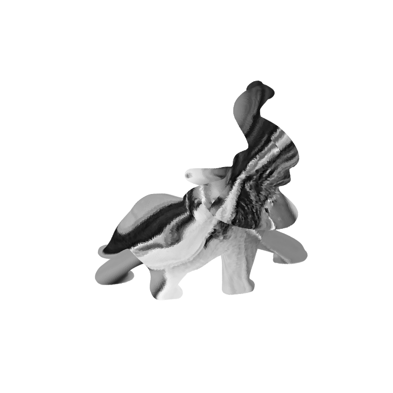

```python
fig = plt.figure(figsize=(10, 10))
ax = fig.add_subplot(111, projection="3d")
ax.scatter(X0[0, :], X0[1, :], X0[2, :], lw=0, c=my_cmap, s=30)
ax.axis("off")
ax.view_init(elev=90, azim=-90)
ax.dist = 6
```

The operator $\tilde W : \RR^n \rightarrow \RR^n$ can be used to smooth a function $f$, simply by computing $\tilde W f \in \RR^n$.

To further smooth the mesh, it is possible to iterate this process, by defining $f^{(0)} = f$ and

$$ f^{(\ell+1)} = \tilde W f^{(\ell)}.$$

Note that one has $ f^{(\ell)} = \tilde W^{\ell} f, $ but it is preferable to use the iterative algorithm to do the computations.

**Worked example 1**

Display the evolution of the image on the mesh as the number of iterations increases.

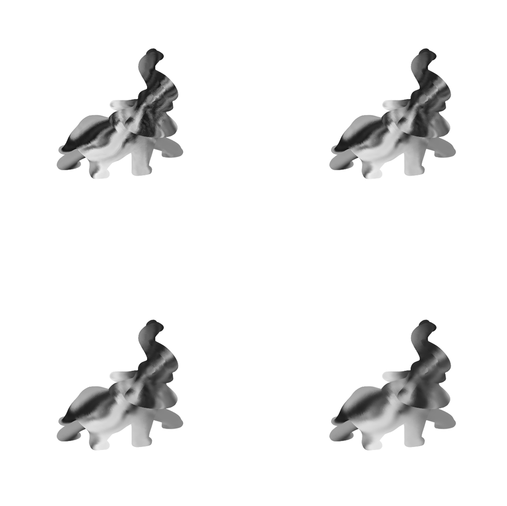

```python
fig = plt.figure(figsize=(15, 15))
klist = [1, 2, 4, 8]
i = 0
f1 = np.copy(f)

for k in range(1, max(klist) + 1):
    f1 = tW.dot(f1)
    if k == klist[i]:
        ax = fig.add_subplot(2, 2, i + 1, projection="3d")
        my_cmap = np.repeat(f1[:, np.newaxis], 3, 1)
        ax.scatter(X0[0, :], X0[1, :], X0[2, :], lw=0, c=my_cmap, s=30)
        ax.axis("off")
        ax.view_init(elev=90, azim=-90)
        ax.dist = 6
        i = i + 1
plt.show()
```

## Mesh Denoising with Filtering

The quality of a noisy mesh is improved by applying local averagings, that removes noise but also tends to smooth features.

The operator $\tilde W : \RR^n \rightarrow \RR^n$ can be used to smooth a function, but it can also be applied to smooth the position $W \in \RR^{3 \times n} $. Since they are stored as row of a matrix, one should applies $\tilde W^*$ (transposed matrix) on the right side. $$ X^{(0)} = X \qandq X^{(\ell+1)} = X^{(\ell)} W^* $$

```python
niter = 5
X1 = np.copy(X)
for i in range(niter):
    X1 = tW.dot(np.transpose(X1)).transpose()
```

We can compute the errors in dB with respect to the clean mesh, using

$$ \text{SNR}(X,Y) = -20 \log_{10} \pa{ \norm{X-Y}/\norm{Y} }. $$

```python
pnoisy = snr(X0, X)
pfilt = snr(X0, X1)
print("Noisy = %.f dB, Denoised = %.f dB" % (pnoisy, pfilt))
```

```
Noisy = 27 dB, Denoised = 40 dB
```

Display the results.

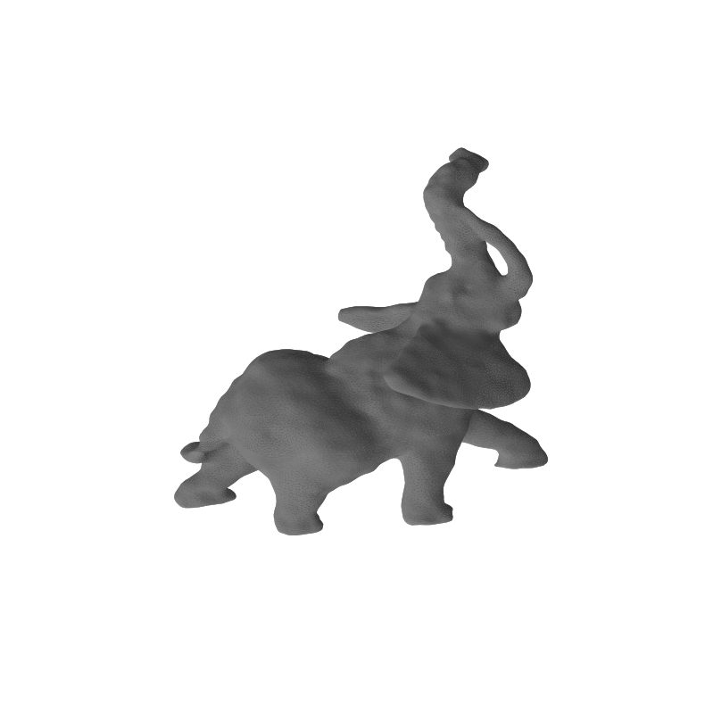

```python
plt.figure(figsize=(10, 10))
plot_mesh(X1, F)
```

**Worked example 2**

Determine the optimal number of iterations to maximize the SNR. Record, for each number $i$ of iteration, the SNR in $err(i)$.

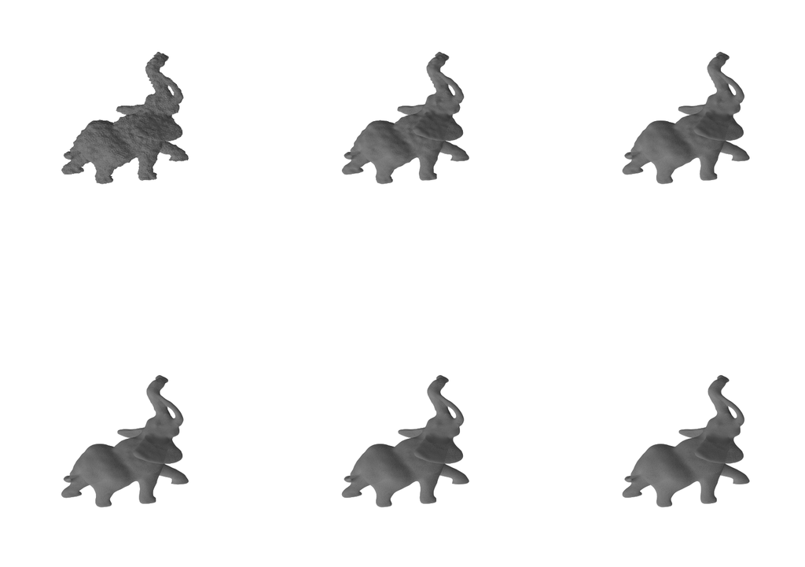

```python
plt.figure(figsize=(20, 15))
X1 = X
err = [pnoisy]

for i in range(1, 13):
    X1 = tW.dot(np.transpose(X1)).transpose()
    err = err + [snr(X0, X1)]

    if i % 2 == 0:
        plot_mesh(X1, F, subplot=[2, 3, i // 2])

    if err[-1] > max(err[:-1]):
        Xbest = X1
```

Plot the error as a function of the number of iterations.

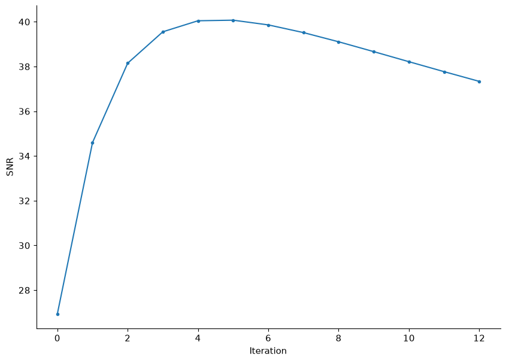

```python
plt.figure(figsize=(10, 7))
plt.plot(err, ".-")
plt.xlabel("Iteration")
plt.ylabel("SNR")
plt.show()
```

## Mesh Denoising with Linear Heat Diffusion

Iterative filtering is closely related to the heat diffusion. The heat diffusion is a linear partial differential equation (PDE) that compute a continuous denoising result for arbitrary time $t$. It is thus more precise than simple iterative filterings.

This PDE defines a function $f_t \in \RR^n$ parameterized by the time $t>0$ as $$ \forall t>0, \quad \pd{f_t}{t} = -\tilde L f_t \qandq f_0 = f, $$ where $ \tilde L $ is the symetric normaled Laplacian defined as $$ \tilde L = D^{-1} L = \text{Id}_n - \tilde W. $$

```python
tL = iD.dot(L)
```

This PDE is applied to the three components of a 3-D mesh to define a surface evolution $$ \forall t>0, \quad \pd{X_t}{t} = -X_t \tilde L^* \qandq f_0 = f. $$

One can approximate the solution to this PDE using explicit finite difference in time (Euler explicit scheme) $$ X^{(\ell+1)} = X^{(\ell)} - \tau X^{(\ell)} \tilde L^* = (1-\tau) X^{(\ell)} + \tau X^{(\ell)} \tilde W^* $$ where $0 < \tau < 1$ is a (small enough) time step and $f^{(\ell)}$ is intended to be an approximation of $X_t$ at time $t=\tau \ell$. The smaller $\tau$, the better the approximation.

One can see that with $\tau=1$, one recovers the iterative filtering method.

Time step $\tau$.

```python
tau = 0.2
```

Maximum time of resolution.

```python
Tmax = 40
```

Number of iterations needed to reach this time.

```python
niter = int(np.ceil(Tmax / tau))
```

Initial solution at time $t=0$.

```python
Xt = np.copy(X)
```

We use an explicit discretization in time of the PDE. Here is one iteration.

```python
Xt = Xt - tau * (tL.dot(np.transpose(Xt))).transpose()
```

**Worked example 3**

Compute the linear heat diffusion. Monitor the denoising SNR $err(l)$ between $X_t$ and $X_0$ at iteration index $l$.

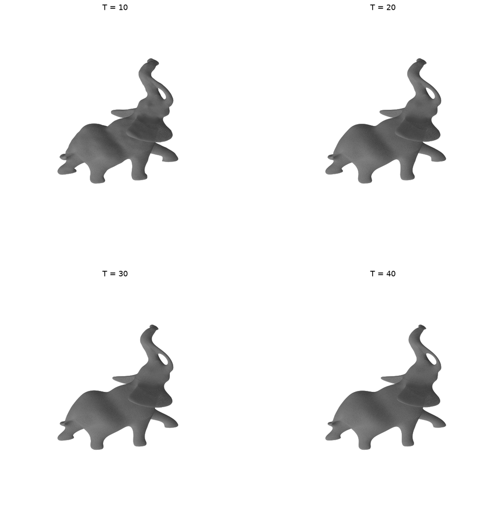

```python
plt.figure(figsize=(15, 15))
Xt = np.copy(X)
k = 0
sob = []
err = []

for i in range(1, niter + 1):
    # step
    Xt = Xt - tau * (tL.dot(np.transpose(Xt))).transpose()
    # error
    err = err + [snr(X0, Xt)]
    if i % np.floor(niter / 4) == 0:
        k = k + 1
        plot_mesh(Xt, F, subplot=[2, 2, k], title="T = %i" % (Tmax * k / 4))
```

Plot the error as a function of time.

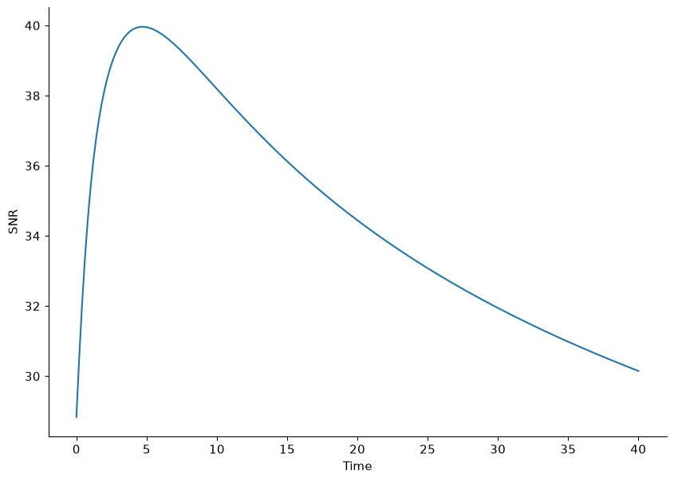

```python
t = np.linspace(0, Tmax, niter)

plt.figure(figsize=(10, 7))
plt.plot(t, err)
plt.xlabel("Time")
plt.ylabel("SNR")
plt.show()
```

## Mesh Denoising with Sobolev Regularization

Instead of solving an evolution PDE, it is possible to do denoising by solving a quadratic regularization.

Denoting $G \in \RR^{p_0 \times n}$ the gradient operator, the Soboleb norm of a signal $f \in \RR^n$ is defined as $$ J(f) = \norm{G f}^2 = \dotp{L f}{f}. $$ It is extended to mesh poisition $X \in \RR^{3 \times n}$ as $$ J(X) = \norm{X G^*}^2 = \dotp{X L}{X}, $$ (remeber that $L$ is symmetric).

Denoising of a noisy set of vertices $X$ is then defined as the solution of a quadratic minimization $$ X_\mu = \uargmin{Z \in \RR^{3 \times n}} \norm{Z-X}^2 + \mu J(Z)^2. $$ Here $\mu \geq 0$ controls the amount of denoising, and should be proportional to the noise level.

The solution to this problem is obtained by solving the following symmetric linear system $$ X_\mu^* = (\text{Id}_n + \mu L )^{-1} X^* $$ (remember that the mesh vertex position are stored as rows, hence the transposed).

We select a penalization weight $\mu$. The larger, the smoother the result will be (more denoising).

```python
mu = 10
```

We set up the matrix of the system. It is important to use sparse matrix to have fast resolution scheme.

```python
A = sparse.identity(n) + mu * L
```

We solve the system for each coordinate of the mesh. Since the matrix is highly sparse, it is very interesting to use an iterative method to solve the system, so here we use a conjugate gradient descent (function cg from sparse.linalg).

```python
Xmu = np.copy(X)
for i in range(3):
    b = X[i, :]
    Xmu[i, :] = sparse.linalg.cg(A, b)[0].transpose()
```

Display the result.

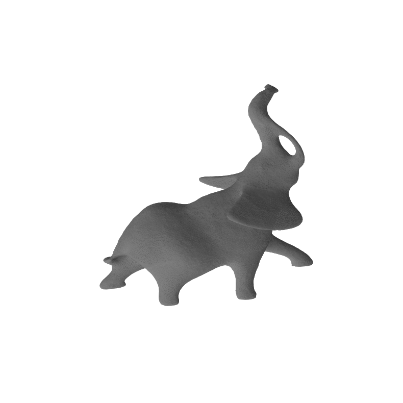

```python
plt.figure(figsize=(10, 10))
plot_mesh(Xmu, F)
```

**Worked example 4**

Solve this problem for various $\mu$ on a 3D mesh. Draw the evolution of the SNR denoising error as a function of $\mu$.

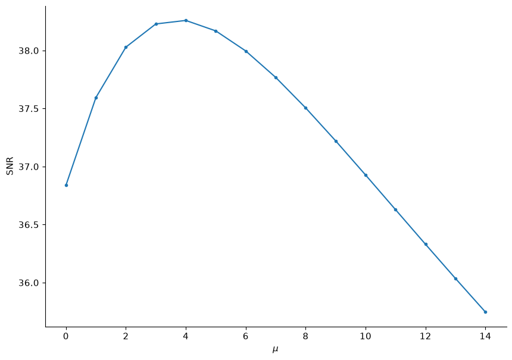

```python
ntests = 15
muList = np.linspace(3, 15, ntests) / 5.0
errR = []

for i in range(ntests):
    mu = muList[i]
    A = sparse.identity(n) + mu * L

    for k in range(3):
        Xmu[k, :] = sparse.linalg.cg(A, X[k, :])[0].transpose()

    errR = errR + [snr(X0, Xmu)]

plt.figure(figsize=(10, 7))
plt.plot(errR, ".-")
plt.xlabel(r"$\mu$")
plt.ylabel("SNR")
plt.show()
```

## References and further reading

- Mario Botsch, Leif Kobbelt, Mark Pauly, Pierre Alliez, and Bruno Lévy. [Polygon Mesh Processing](https://www.pmp-book.org/). 2010, AK Peters. Discrete differential operators, smoothing, and parameterization.
- Michael S. Floater. Parametrization and Smooth Approximation of Surface Triangulations. 1997, Computer Aided Geometric Design 14(3), 231–250. Barycentric mappings of a mesh into a planar domain.
- Mathieu Desbrun, Mark Meyer, Peter Schröder, and Alan H. Barr. [Implicit Fairing of Irregular Meshes Using Diffusion and Curvature Flow](https://doi.org/10.1145/311535.311576). 1999, SIGGRAPH, 317–324. Laplacian smoothing and stable geometric diffusion.
- Gilbert Strang. [Linear Algebra and Learning from Data](https://math.mit.edu/~gs/learningfromdata/). 2019, Wellesley-Cambridge Press. Matrix factorizations, least squares, and low-rank representations.
- Gabriel Peyré. [Advanced Signal, Image and Surface Processing](https://www.numerical-tours.com/book/AdvancedSignalProcessing.pdf). 2010, course notes. A mathematical companion to the Numerical Tours.